# Model the Iris Data (KNN)

# 2) KNN Classification Model

1. Normalise the data
2. Training and Test Separation
3. Random Sampling
4. Remove labels from Test and Training Data
5. Train the model
6. Test the model

## Normalise the variables in the dataset - Z SCORE STANDARDISATION

This allows for each variable to be fairly weighted and not affected by one variable orders of magnitudes bigger than the others here

Sigma = 1 (Standard Deviation) Mu = 0 (Mean)

### scale() function

https://www.r-bloggers.com/r-tutorial-series-centering-variables-and-generating-z-scores-with-the-scale-function/ x = a numeric object (eg column in data frame) center = TRUE the means subtracted to center around 0 scale = TRUE the centered column values divided by standard deviation (both true use the root mean square & a z score is calculated)

```r
iris_norm <- iris %>%
  mutate_each_(funs(scale(.) %>% as.vector),
               vars= c('Sepal.Length','Sepal.Width','Petal.Length','Petal.Width'))
summary(iris_norm)
```

```
  Sepal.Length       Sepal.Width       Petal.Length      Petal.Width            Species       Flower
 Min.   :-1.86378   Min.   :-2.4258   Min.   :-1.5623   Min.   :-1.4422   setosa    :50   Min.   :  1.00
 1st Qu.:-0.89767   1st Qu.:-0.5904   1st Qu.:-1.2225   1st Qu.:-1.1799   versicolor:50   1st Qu.: 38.25
 Median :-0.05233   Median :-0.1315   Median : 0.3354   Median : 0.1321   virginica :50   Median : 75.50
 Mean   : 0.00000   Mean   : 0.0000   Mean   : 0.0000   Mean   : 0.0000                   Mean   : 75.50
 3rd Qu.: 0.67225   3rd Qu.: 0.5567   3rd Qu.: 0.7602   3rd Qu.: 0.7880                   3rd Qu.:112.75
 Max.   : 2.48370   Max.   : 3.0805   Max.   : 1.7799   Max.   : 1.7064                   Max.   :150.00
```

### Do the same for the LONG tibble and WIDE tibble

```r
#recreate long form
long_iris_norm <- iris_norm %>%
  gather(key= 'part', value = 'value', Sepal.Length, Sepal.Width, Petal.Length, Petal.Width) %>%
  separate(part,c('part','measure'), sep = '\\.')
#coerce characters into factors
factors <- c('part','measure')
long_iris_norm[factors] <- lapply(long_iris[factors],as.factor)
#recreate wide form
wide_iris_norm <- iris_norm %>%
  gather(key='key', value='value', -Species, -Flower) %>%
  separate(key, c('Part','Measure'), sep= "\\.") %>%
  spread(Measure, value)
```

## Separate into TRAINING and TEST data

```r
#set seed to make work reproducible
set.seed(12345)
#create sample vector (sample into 2 groups, probabilities set @ 67% : 33%)
sample_set <- sample(2, nrow(iris_norm), replace=TRUE, prob= c(0.67, 0.33))
#add 'sample label' to tibble for subsetting later
iris_norm['sample_set'] <- sample_set
iris_norm
```

| Sepal.Length | Sepal.Width | Petal.Length | Petal.Width | Species | Flower | sample_set |
| --- | --- | --- | --- | --- | --- | --- |
| -0.89767388 | 1.01560199 | -1.33575163 | -1.3110521482 | setosa | 1 | 2 |
| -1.13920048 | -0.13153881 | -1.33575163 | -1.3110521482 | setosa | 2 | 2 |
| -1.38072709 | 0.32731751 | -1.39239929 | -1.3110521482 | setosa | 3 | 2 |
| -1.50149039 | 0.09788935 | -1.27910398 | -1.3110521482 | setosa | 4 | 2 |
| -1.01843718 | 1.24503015 | -1.33575163 | -1.3110521482 | setosa | 5 | 1 |
| -0.53538397 | 1.93331463 | -1.16580868 | -1.0486667950 | setosa | 6 | 1 |
| -1.50149039 | 0.78617383 | -1.33575163 | -1.1798594716 | setosa | 7 | 1 |
| -1.01843718 | 0.78617383 | -1.27910398 | -1.3110521482 | setosa | 8 | 1 |
| -1.74301699 | -0.36096697 | -1.33575163 | -1.3110521482 | setosa | 9 | 2 |
| -1.13920048 | 0.09788935 | -1.27910398 | -1.4422448248 | setosa | 10 | 2 |

[output cut: 140 more lines]

N.B: the ‘replace =’ argument is set to TRUE: this means that you assign a 1 or a 2 to EVERY ROW (if it was false you wouldn’t be able to reapply 1/2 to the rows). you assign a 1 or a 2 to a certain row and then reset the vector of 2 to its original state. This means that, for the next rows in your data set, you can either assign a 1 or a 2, each time again. The probability of choosing a 1 or a 2 should not be proportional to the weights amongst the remaining items, so you specify probability weights.

## Subset TRAIN & TEST data (and remove labels)

90 Values in TRAINING data 60 Values in TEST data

```r
#training and test variables taken (remove labels)
iris_training <- iris_norm[sample_set==1,1:4]
iris_test <- iris_norm[sample_set==2,1:4]
#training and test LABELS extracted
iris_training_labels <- iris_norm[sample_set==1,5]
iris_test_labels <- iris_norm[sample_set==2,5]
count(iris_training)
```

| n |
| --- |
| 90 |

```r
count(iris_test)
```

| n |
| --- |
| 60 |

## Train the model using caret()

NB the model is called ‘iris_train’

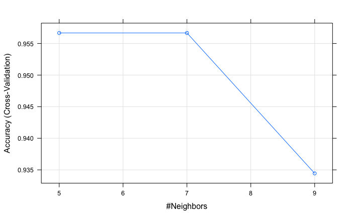

```r
#train the model using the 60% of data
iris_train <- train(Species ~ ., iris_norm_train,
                   method = "knn",
                   trControl = trainControl(method = "cv")
)
#plot the best value for k
plot(iris_train)
```

```r
#NOTE: the function loops through to find the best value for k (k = 5) nb: changes because cv sampling changes accuracy each time
```

### NOTE: K FOLD Cross Validation of the model used

https://kevinzakka.github.io/2016/07/13/k-nearest-neighbor/ trControl = trainControl(method=‘cv’) = what? - a method that can be used to tune the hyperparameter K (k fold different to K) why? - the best K is the one that corresponds to the lowest test error rate, so let’s suppose we carry out repeated measurements of the test error for different values of K. Inadvertently, what we are doing is using the test set as a training set! (OVERFITTING) - An alternative and smarter approach involves estimating the test error rate by holding out a subset of the training set from the fitting process. This subset, called the validation set How? - randomly dividing the training set into k groups, or folds, of approximately equal size - first fold is treated as a validation set, and the method is fit on the remaining k−1 folds - misclassification rate is then computed on the observations in the held-out fold. - This procedure is repeated k times; each time, a different group of observations is treated as a validation set. Output? - This process results in k estimates of the test error which are then averaged out

## Test the model

```r
#test using new data to get predictions
iris_pred <- predict(iris_train, newdata = iris_norm_test)
iris_norm_test_1 <- iris_norm_test %>%

  iris_pred
```

```
Error in function_list[[k]](value) : could not find function "iris_pred"
```

## Assess the model (basic)

### Get the overall accuracy (%)